# W3cubDocs

/Docker 1.13

# Docker and AUFS in practice

AUFS was the first storage driver in use with Docker. As a result, it has a long and close history with Docker, is very stable, has a lot of real-world deployments, and has strong community support. AUFS has several features that make it a good choice for Docker. These features enable:

- Fast container startup times.
- Efficient use of storage.
- Efficient use of memory.

Despite its capabilities and long history with Docker, some Linux distributions do not support AUFS. This is usually because AUFS is not included in the mainline (upstream) Linux kernel.

The following sections examine some AUFS features and how they relate to Docker.

## Image layering and sharing with AUFS

AUFS is a *unification filesystem*. This means that it takes multiple directories on a single Linux host, stacks them on top of each other, and provides a single unified view. To achieve this, AUFS uses a *union mount*.

AUFS stacks multiple directories and exposes them as a unified view through a single mount point. All of the directories in the stack, as well as the union mount point, must all exist on the same Linux host. AUFS refers to each directory that it stacks as a *branch*.

Within Docker, AUFS union mounts enable image layering. The AUFS storage driver implements Docker image layers using this union mount system. AUFS branches correspond to Docker image layers. The diagram below shows a Docker container based on the `ubuntu:latest` image.

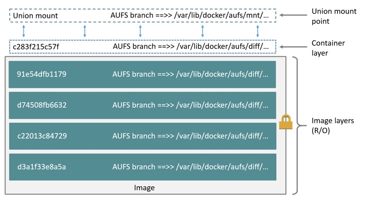

This diagram shows that each image layer, and the container layer, is represented in the Docker hosts filesystem as a directory under `/var/lib/docker/`. The union mount point provides the unified view of all layers. As of Docker 1.10, image layer IDs do not correspond to the names of the directories that contain their data.

AUFS also supports the copy-on-write technology (CoW). Not all storage drivers do.

## Container reads and writes with AUFS

Docker leverages AUFS CoW technology to enable image sharing and minimize the use of disk space. AUFS works at the file level. This means that all AUFS CoW operations copy entire files - even if only a small part of the file is being modified. This behavior can have a noticeable impact on container performance, especially if the files being copied are large, below a lot of image layers, or the CoW operation must search a deep directory tree.

Consider, for example, an application running in a container needs to add a single new value to a large key-value store (file). If this is the first time the file is modified, it does not yet exist in the container’s top writable layer. So, the CoW must *copy up* the file from the underlying image. The AUFS storage driver searches each image layer for the file. The search order is from top to bottom. When it is found, the entire file is *copied up* to the container’s top writable layer. From there, it can be opened and modified.

Larger files obviously take longer to *copy up* than smaller files, and files that exist in lower image layers take longer to locate than those in higher layers. However, a *copy up* operation only occurs once per file on any given container. Subsequent reads and writes happen against the file’s copy already *copied-up* to the container’s top layer.

## Deleting files with the AUFS storage driver

The AUFS storage driver deletes a file from a container by placing a *whiteout file* in the container’s top layer. The whiteout file effectively obscures the existence of the file in the read-only image layers below. The simplified diagram below shows a container based on an image with three image layers.

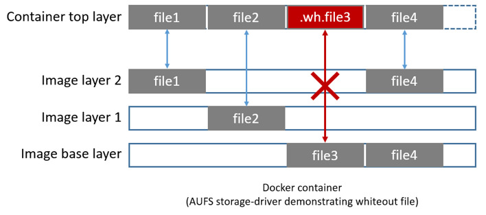

The `file3` was deleted from the container. So, the AUFS storage driver placed a whiteout file in the container’s top layer. This whiteout file effectively “deletes” `file3` from the container by obscuring any of the original file’s existence in the image’s read-only layers. This works the same no matter which of the image’s read-only layers the file exists in.

## Renaming directories with the AUFS storage driver

Calling `rename(2)` for a directory is not fully supported on AUFS. It returns `EXDEV` (“cross-device link not permitted”), even when both of the source and the destination path are on a same AUFS layer, unless the directory has no children.

So your application has to be designed so that it can handle `EXDEV` and fall back to a “copy and unlink” strategy.

## Configure Docker with AUFS

### Prerequisites

You can only use the AUFS storage driver on Linux systems with AUFS installed. Use the following command to determine if your system supports AUFS.

```
$ grep aufs /proc/filesystems

nodev   aufs
```

This output indicates the system supports AUFS. If you get no output, your system does not support AUFS. To address this:

- Upgrade your host system’s kernel to 3.13 or higher. It is recommended to install the kernel headers when you upgrade.
- **Ubuntu or Debian**: In addition to updating the kernel if necessary, install the `linux-image-extra-*` packages:

  ```
  $ sudo apt-get install linux-image-extra-$(uname -r) \
                         linux-image-extra-virtual
  ```

### Configuration

When you have verified that you meet the prerequisites, instruct the Docker daemon to use AUFS by starting the Docker daemon with the flag `--storage-driver=aufs`:

```
$ sudo dockerd --storage-driver=aufs &
```

To make the change permanent, you can edit the Docker configuration file and add the `--storage-driver=aufs` option to the `DOCKER_OPTS` line.

```
# Use DOCKER_OPTS to modify the daemon startup options.
DOCKER_OPTS="--storage-driver=aufs"
```

After the daemon starts, verify the default storage driver using the `docker info` command:

```
$ sudo docker info

Containers: 1
Images: 4
Storage Driver: aufs
 Root Dir: /var/lib/docker/aufs
 Backing Filesystem: extfs
 Dirs: 6
 Dirperm1 Supported: false
Execution Driver: native-0.2
...output truncated...
```

Look for the `Storage Driver` line. If its value is `aufs`, the Docker daemon is using the AUFS storage driver on top of the filesystem listed on the `Backing Filesystem` line.

## Local storage and AUFS

As the `dockerd` runs with the AUFS driver, the driver stores images and containers within the Docker host’s local storage area under `/var/lib/docker/aufs/`.

### Images

Image layers and their contents are stored under `/var/lib/docker/aufs/diff/`. With Docker 1.10 and higher, image layer IDs do not correspond to directory names.

The `/var/lib/docker/aufs/layers/` directory contains metadata about how image layers are stacked. This directory contains one file for every image or container layer on the Docker host (though file names no longer match image layer IDs). Inside each file are the names of the directories that exist below it in the stack.

The command below shows the contents of a metadata file in `/var/lib/docker/aufs/layers/` that lists the three directories that are stacked below it in the union mount. Remember, these directory names do no map to image layer IDs with Docker 1.10 and higher.

```
$ cat /var/lib/docker/aufs/layers/91e54dfb11794fad694460162bf0cb0a4fa710cfa3f60979c177d920813e267c

d74508fb6632491cea586a1fd7d748dfc5274cd6fdfedee309ecdcbc2bf5cb82
c22013c8472965aa5b62559f2b540cd440716ef149756e7b958a1b2aba421e87
d3a1f33e8a5a513092f01bb7eb1c2abf4d711e5105390a3fe1ae2248cfde1391
```

The base layer in an image has no image layers below it, so its file is empty.

### Containers

Running containers are mounted below `/var/lib/docker/aufs/mnt/<container-id>`. This is where the AUFS union mount point that exposes the container and all underlying image layers as a single unified view exists. If a container is not running, it still has a directory here but it is empty. This is because AUFS only mounts a container when it is running. With Docker 1.10 and higher, container IDs no longer correspond to directory names under `/var/lib/docker/aufs/mnt/<container-id>`.

Container metadata and various config files that are placed into the running container are stored in `/var/lib/docker/containers/<container-id>`. Files in this directory exist for all containers on the system, including ones that are stopped. However, when a container is running the container’s log files are also in this directory.

A container’s thin writable layer is stored in a directory under `/var/lib/docker/aufs/diff/`. With Docker 1.10 and higher, container IDs no longer correspond to directory names. However, the containers thin writable layer still exists here and is stacked by AUFS as the top writable layer and is where all changes to the container are stored. The directory exists even if the container is stopped. This means that restarting a container will not lose changes made to it. Once a container is deleted, its thin writable layer in this directory is deleted.

## AUFS and Docker performance

To summarize some of the performance related aspects already mentioned:

- The AUFS storage driver is a good choice for PaaS and other similar use-cases where container density is important. This is because AUFS efficiently shares images between multiple running containers, enabling fast container start times and minimal use of disk space.
- The underlying mechanics of how AUFS shares files between image layers and containers uses the systems page cache very efficiently.
- The AUFS storage driver can introduce significant latencies into container write performance. This is because the first time a container writes to any file, the file has to be located and copied into the containers top writable layer. These latencies increase and are compounded when these files exist below many image layers and the files themselves are large.

One final point. Data volumes provide the best and most predictable performance. This is because they bypass the storage driver and do not incur any of the potential overheads introduced by thin provisioning and copy-on-write. For this reason, you may want to place heavy write workloads on data volumes.

## AUFS compatibility

To summarize the AUFS’s aspect which is incompatible with other filesystems:

- The AUFS does not fully support the `rename(2)` system call. Your application needs to detect its failure and fall back to a “copy and unlink” strategy.

## Related information

- Understand images, containers, and storage drivers
- Select a storage driver
- Btrfs storage driver in practice
- Device Mapper storage driver in practice